# Introducción al modelo lineal

Miguel Ángel Muñoz

07/03/2023

# Ejercicios iniciales

## Ejercicio 1

Con los datos de los buitres leonados

```r
heartbpm <- c(47.53, 48.27, 49.51, 51.09, 52.57, 54.30,
              54.25, 54.45, 57.95, 60.92, 61.91, 77.92,
              82.07, 82.95, 83.94, 86.96, 90.42, 92.93, 100.05)
metabol <- c(6.15, 6.31, 6.43, 6.78, 6.86, 6.90, 7.37, 7.41,
             8.24, 9.22, 8.16, 12.61, 15.26, 13.09, 14.59,
             17.35, 18.57, 19.00, 20.70)
vulture <-data.frame(heartbpm,metabol)
rm(heartbpm,metabol)
attach(vulture)
```

### Apartado A/B

Dibujar la nube de puntos con la instrucción plot() y añadir la recta de regresión con la instrucción abline()

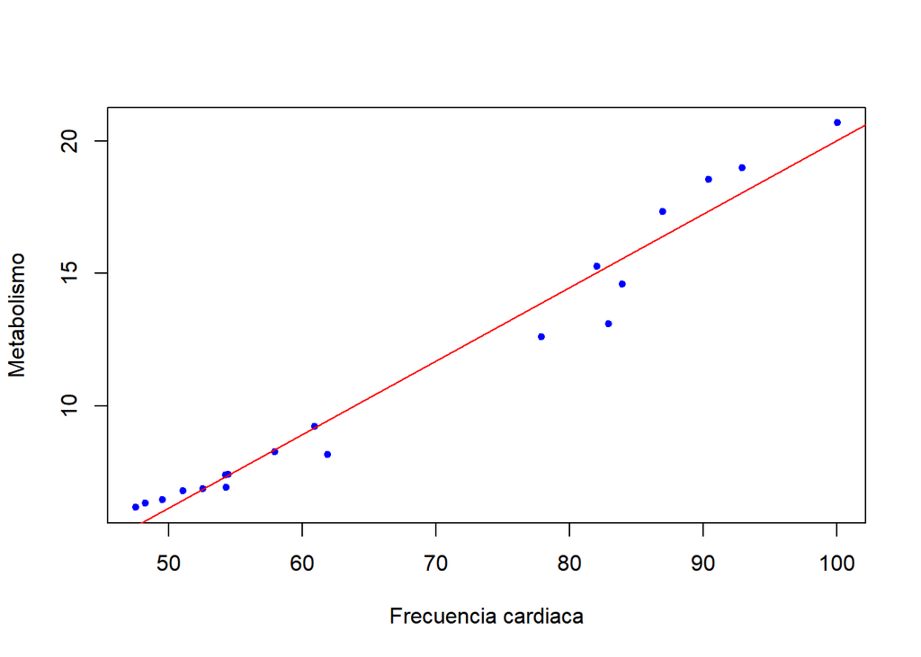

```r
plot(heartbpm,metabol,pch=20,col="blue",xlab = "Frecuencia cardiaca", ylab = "Metabolismo")
recta <- lm(metabol~heartbpm)
abline(recta$coefficients,col="red")
```

### Apartado C

Dibujar el gráfico de residuos vs. valores ajustados con la función plot() aplicada al objeto lm

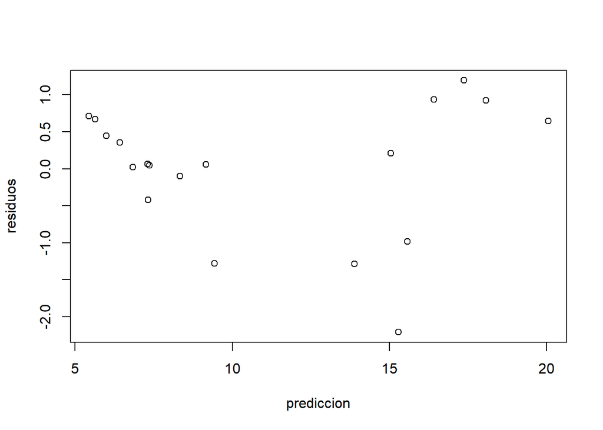

```r
residuos <- recta$residuals
prediccion <- recta$fitted.values
plot(prediccion,residuos)
```

### Apartado D

Añadir al gráfico de dispersión del apartado (a) la curva de regresión parabólica

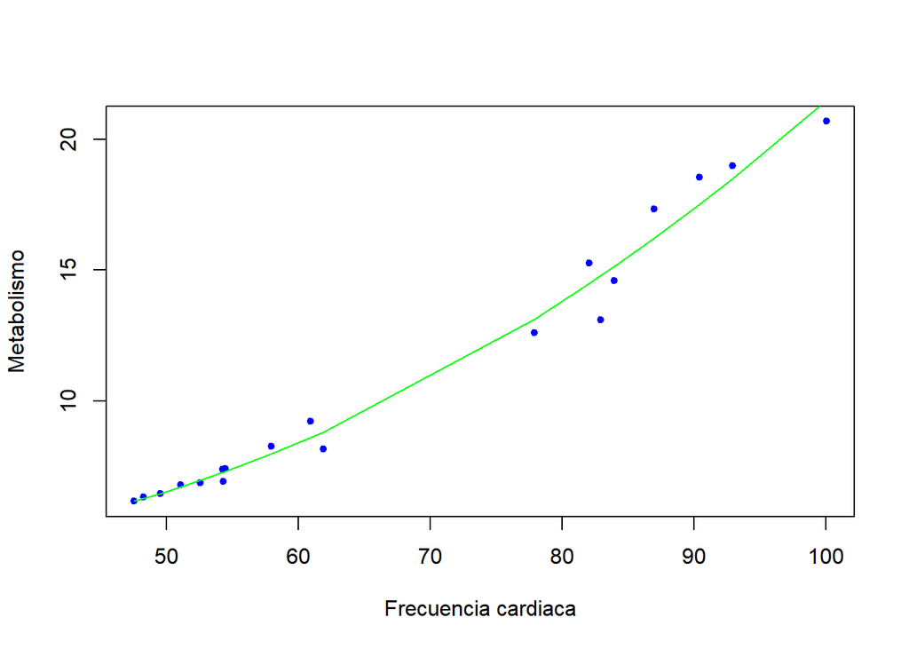

```r
plot(heartbpm,metabol,pch=20,col="blue",xlab = "Frecuencia cardiaca", ylab = "Metabolismo")
heartbpm2 <- heartbpm ^ 2
parabola <- lm (metabol ~ heartbpm + heartbpm2)
lines(heartbpm, parabola$fitted.values, col='green')
```

## Ejercicio 2

Con los datos de la tensión arterial sistólica y la edad de los 69 pacientes calcular los coeficientes de regresión de la recta mínimo cuadrática.

```r
tension <- c(114,134,124,128,116,120,138,130,139,125,132,130,140,144,110,
             148,124,136,150,120,144,153,134,152,158,124,128,138,142,160,
             135,138,142,145,149,156,159,130,157,142,144,160,174,156,158,
             174,150,154,165,164,168,140,170,185,154,169,172,144,162,158,
             162,176,176,158,170,172,184,175,180)
edad <- c(17,18,19,19,20,21,21,22,23,25,26,29,33,33,34,35,36,36,
          38,39,39,40,41,41,41,42,42,42,44,44,45,45,46,47,47,47,
          47,48,48,50,50,51,51,52,53,55,56,56,56,57,57,59,59,60,
          61,61,62,63,64,65,65,65,66,67,67,68,68,69,70)

recta <- lm(tension~edad)
recta$coefficients
```

```
## (Intercept)        edad
## 103.3526585   0.9835585
```

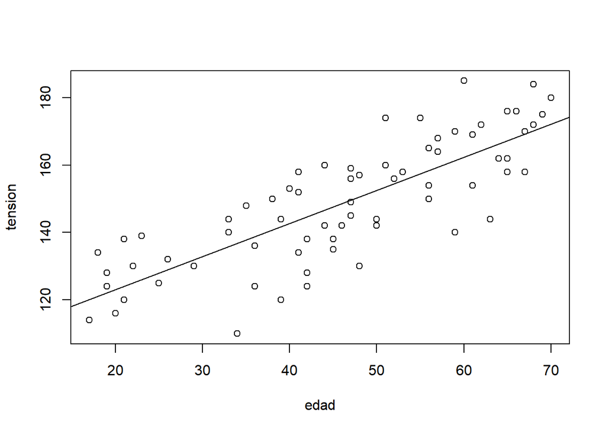

```r
plot(edad,tension)
abline(recta$coefficients)
```

# Ejercicios del libro de Faraway

```r
library(faraway)
```

## Ejercicio 1

The dataset `teengamb` concerns a study of teenage gambling in Britain. Make a numerical and graphical summary of the data, commenting on any features that you find interesting

```r
data("teengamb")
head(teengamb)
```

```
##   sex status income verbal gamble
## 1   1     51   2.00      8    0.0
## 2   1     28   2.50      8    0.0
## 3   1     37   2.00      6    0.0
## 4   1     28   7.00      4    7.3
## 5   1     65   2.00      8   19.6
## 6   1     61   3.47      6    0.1
```

```r
str(teengamb)
```

```
## 'data.frame':    47 obs. of  5 variables:
##  $ sex   : int  1 1 1 1 1 1 1 1 1 1 ...
##  $ status: int  51 28 37 28 65 61 28 27 43 18 ...
##  $ income: num  2 2.5 2 7 2 3.47 5.5 6.42 2 6 ...
##  $ verbal: int  8 8 6 4 8 6 7 5 6 7 ...
##  $ gamble: num  0 0 0 7.3 19.6 0.1 1.45 6.6 1.7 0.1 ...
```

```r
teengamb$sex <- factor(teengamb$sex,labels = c('male','female'))
teengamb$verbal <- factor(teengamb$verbal)
summary(teengamb)
```

```
##      sex         status          income           verbal       gamble
##  male  :28   Min.   :18.00   Min.   : 0.600   6      :12   Min.   :  0.0
##  female:19   1st Qu.:28.00   1st Qu.: 2.000   8      :10   1st Qu.:  1.1
##              Median :43.00   Median : 3.250   7      : 9   Median :  6.0
##              Mean   :45.23   Mean   : 4.642   9      : 6   Mean   : 19.3
##              3rd Qu.:61.50   3rd Qu.: 6.210   4      : 4   3rd Qu.: 19.4
##              Max.   :75.00   Max.   :15.000   5      : 3   Max.   :156.0
##                                               (Other): 3
```

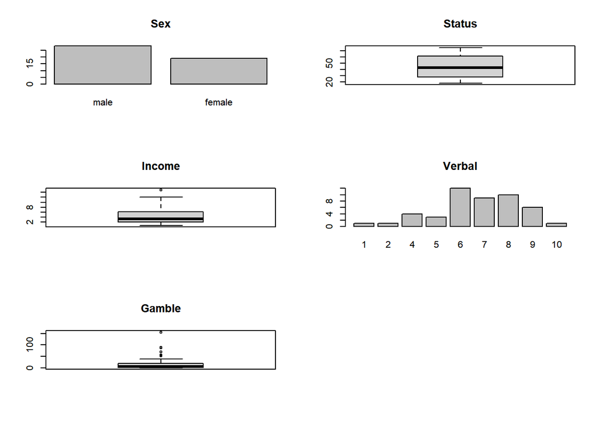

```r
par(mfrow = c(3,2))
plot(teengamb$sex, main = "Sex")
boxplot(teengamb$status, main = "Status")
boxplot(teengamb$income, main = "Income")
plot(teengamb$verbal, main = "Verbal")
boxplot(teengamb$gamble, main = "Gamble")
```

## Ejercicio 2

The dataset `uswages` is drawn as a sample from the Current Population Survey in 1988. Make a numerical and graphical summary of the data as in the previous question.

```r
data("uswages")
head(uswages)
```

```
##         wage educ exper race smsa ne mw so we pt
## 6085  771.60   18    18    0    1  1  0  0  0  0
## 23701 617.28   15    20    0    1  0  0  0  1  0
## 16208 957.83   16     9    0    1  0  0  1  0  0
## 2720  617.28   12    24    0    1  1  0  0  0  0
## 9723  902.18   14    12    0    1  0  1  0  0  0
## 22239 299.15   12    33    0    1  0  0  0  1  0
```

```r
str(uswages)
```

```
## 'data.frame':    2000 obs. of  10 variables:
##  $ wage : num  772 617 958 617 902 ...
##  $ educ : int  18 15 16 12 14 12 16 16 12 12 ...
##  $ exper: int  18 20 9 24 12 33 42 0 36 37 ...
##  $ race : int  0 0 0 0 0 0 0 0 0 0 ...
##  $ smsa : int  1 1 1 1 1 1 1 1 1 0 ...
##  $ ne   : int  1 0 0 1 0 0 0 0 0 0 ...
##  $ mw   : int  0 0 0 0 1 0 0 1 0 1 ...
##  $ so   : int  0 0 1 0 0 0 1 0 0 0 ...
##  $ we   : int  0 1 0 0 0 1 0 0 1 0 ...
##  $ pt   : int  0 0 0 0 0 0 1 1 1 0 ...
```

```r
uswages$race <- factor(uswages$race)
uswages$smsa <- factor(uswages$smsa)
uswages$ne <- factor(uswages$ne)
uswages$mw <- factor(uswages$mw)
uswages$so <- factor(uswages$so)
uswages$we <- factor(uswages$we)
uswages$pt <- factor(uswages$pt)
#Eliminamos los valores negativos
uswages$exper[uswages$exper<0] <- NA
summary(uswages)
```

```
##       wage              educ           exper       race     smsa     ne
##  Min.   :  50.39   Min.   : 0.00   Min.   : 0.00   0:1844   0: 488   0:1542
##  1st Qu.: 308.64   1st Qu.:12.00   1st Qu.: 8.00   1: 156   1:1512   1: 458
##  Median : 522.32   Median :12.00   Median :16.00
##  Mean   : 608.12   Mean   :13.11   Mean   :18.74
##  3rd Qu.: 783.48   3rd Qu.:16.00   3rd Qu.:27.00
##  Max.   :7716.05   Max.   :18.00   Max.   :59.00
##                                    NA's   :33
##  mw       so       we       pt
##  0:1503   0:1375   0:1580   0:1815
##  1: 497   1: 625   1: 420   1: 185
##
##
##
##
##
```

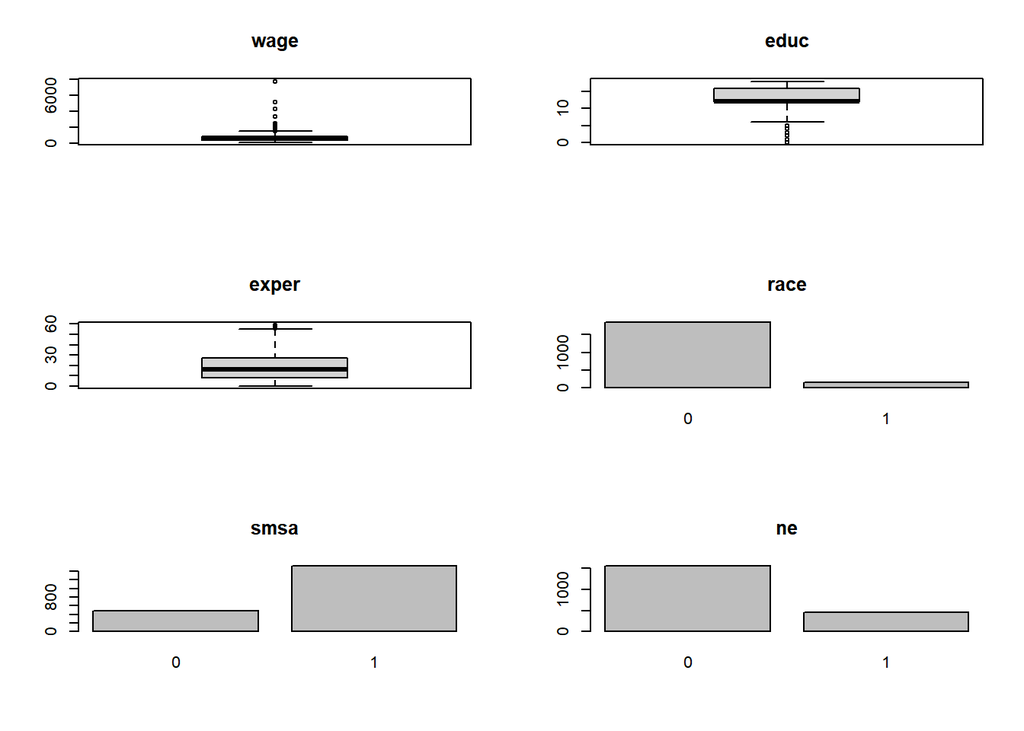

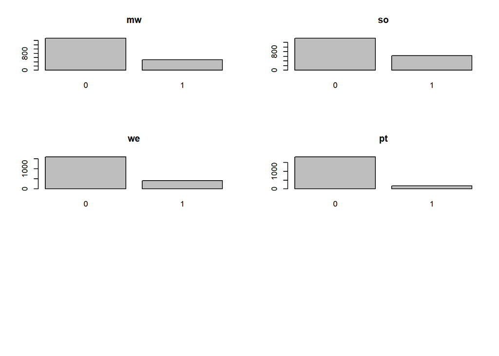

```r
par(mfrow = c(3,2))

for (i in 1:dim(uswages)[2]){
  if (class(uswages[,i]) == 'factor'){
    plot(uswages[,i], main = colnames(uswages)[i])
  } else {
    boxplot(uswages[,i], main = colnames(uswages)[i])
  }
}
```

# Ejercicios del libro de Carmona

## Ejercicio 3

Consideremos el problema de tráfico planteado en el apartado 1.2 de este capítulo, con la variable independiente densidad y la variable dependiente raíz cuadrada de la velocidad. Con los datos proporcionados en la tabla 1.1

```r
densidad <- c(12.7,17.0,66.0,50.0,87.8,81.4,75.6,66.2,81.1,62.8,77.0,89.6,
          18.3,19.1,16.5,22.2,18.6,66.0,60.3,56.0,66.3,61.7,66.6,67.8)
velocidad <- c(62.4,50.7,17.1,25.9,12.4,13.4,13.7,17.9,13.8,17.9,15.8,12.6,
         51.2,50.8,54.7,46.5,46.3,16.9,19.8,21.2,18.3,18.0,16.6,18.3)
rvelocidad <- sqrt(velocidad)
```

### Apartado A

Dibujar nube de puntes y recta que pasa por los puntos (12.7,√62.4) y (87.8,√12.4)

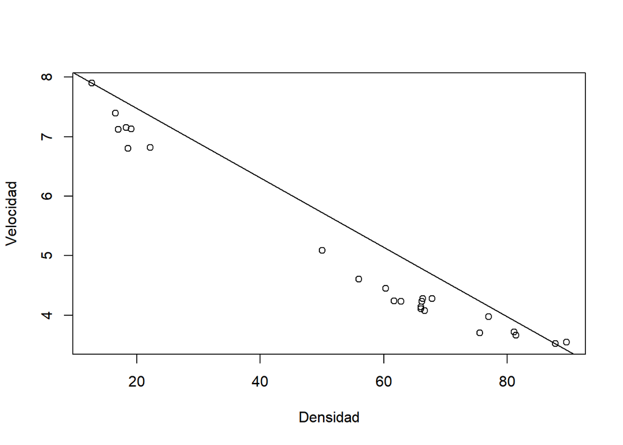

```r
x <- c(12.7, 87.8)
y <- sqrt(c(62.4,12.4))
slope <- diff(y)/diff(x)
intercept <- y[1]-slope*x[1]
plot(densidad,rvelocidad,xlab = "Densidad", ylab = "Velocidad")
abline(c(intercept, slope))
```

Dibujar el gráfico de los residuos con la densidad y el gráfico con las predicciones. Calcular la suma de cuadrados de residuos

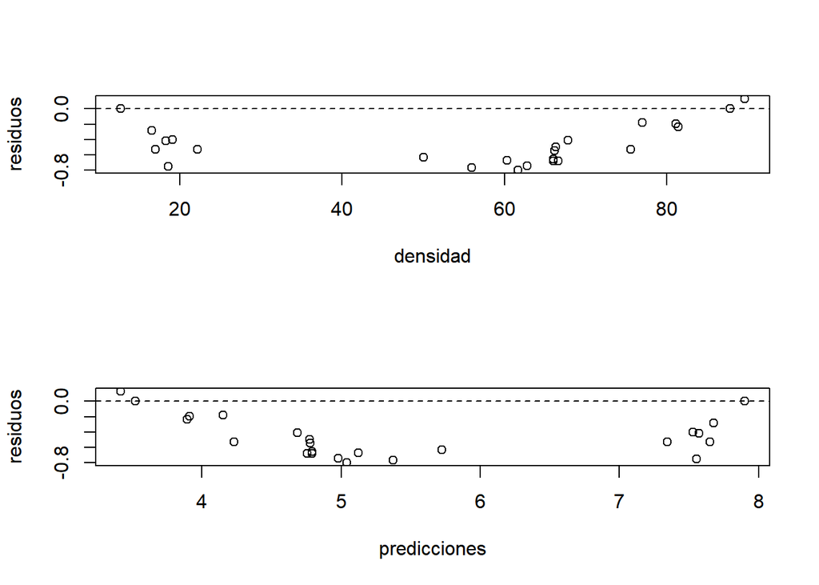

```r
predicciones <- intercept + slope * densidad
residuos <- rvelocidad - predicciones
par(mfrow=c(2,1))
plot(densidad,residuos)
abline(h=0,lty=2)
plot(predicciones,residuos)
abline(h=0,lty=2)
```

```r
sum(residuos^2)
```

```
## [1] 6.689836
```

### Apartado B

Hallar la recta de regresión simple. Dibujar el gráfico de los residuos con la densidad y el gráfico con las predicciones. Calcular la suma de cuadrados de los residuos

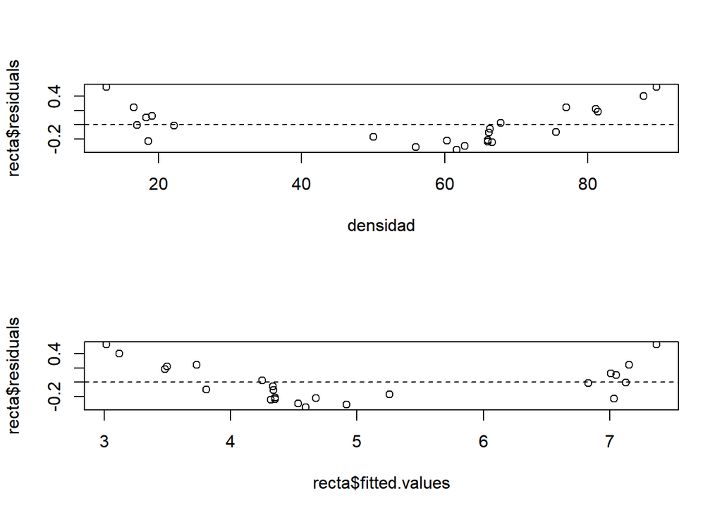

```r
recta <- lm(rvelocidad ~ densidad)
par(mfrow=c(2,1))
plot(densidad,recta$residuals)
abline(h=0,lty=2)
plot(recta$fitted.values,recta$residuals)
abline(h=0,lty=2)
```

```r
sum(recta$residuals^2)
```

```
## [1] 1.591218
```

### Apartado C

Mejorar el modelo anterior considerando una regresión parabólica. Dibujar el gráfico de los residuos con la densidad y el gráfico con las predicciones. Calcular la suma de cuadrados de los residuos

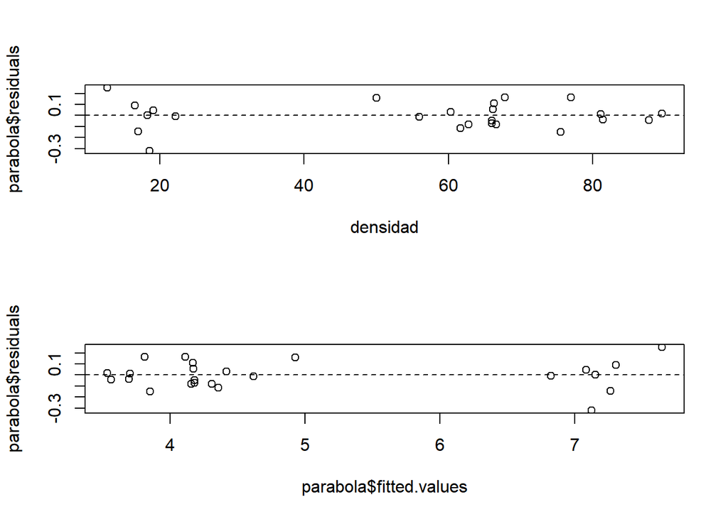

```r
densidad2 <- densidad^2
parabola <- lm(rvelocidad ~ densidad + densidad2)
par(mfrow=c(2,1))
plot(densidad,parabola$residuals)
abline(h=0,lty=2)
plot(parabola$fitted.values,parabola$residuals)
abline(h=0,lty=2)
```

```r
sum(parabola$residuals^2)
```

```
## [1] 0.3534143
```

### Apartado D

Calcular la capacidad de la carretera o punto de máximo flujo. Recordar que flujo = vel × densidad

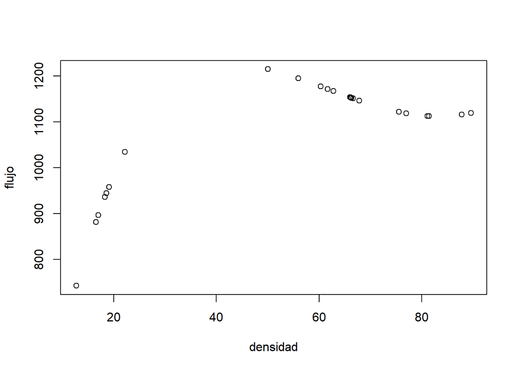

```r
cc <- parabola$coefficients
flujo <- (cc[1] + cc[2]*densidad + cc[3]*densidad^2)^2 * densidad
par(mfrow=c(1,1))
plot(densidad,flujo)
```

```r
max(flujo)
```

```
## [1] 1214.655
```

```r
densidad[which.max(flujo)]
```

```
## [1] 50
```

## Ejercicio 4

La siguiente tabla contiene los mejores tiempos conseguidos en algunas pruebas de velocidad en atletismo en los Juegos Olímpicos de Atlanta

```r
tm_h <- c(9.84,19.32,43.19,102.58,215.78,787.96,1627.34,7956)
tm_m <- c(10.94,22.12,48.25,117.73,240.83,899.88,1861.63,8765)
distancia <- c(100,200,400,800,1500,5000,10000,42192)
```

### Apartado A

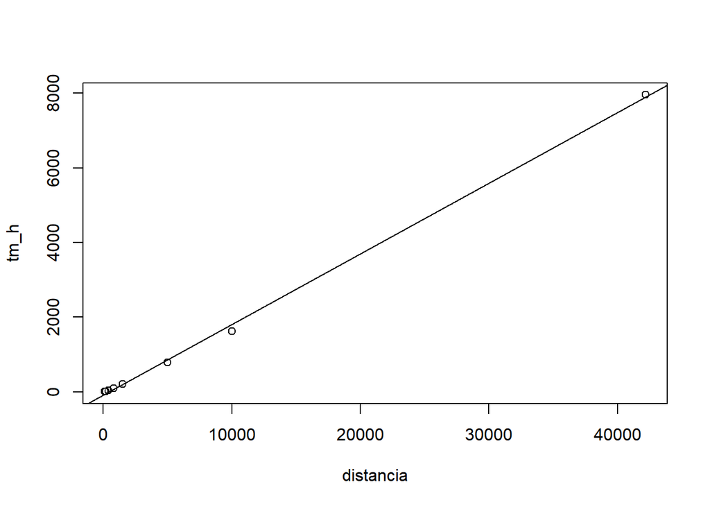

```r
recta_h <- lm(tm_h~distancia)
plot(distancia,tm_h)
abline(recta_h)
```

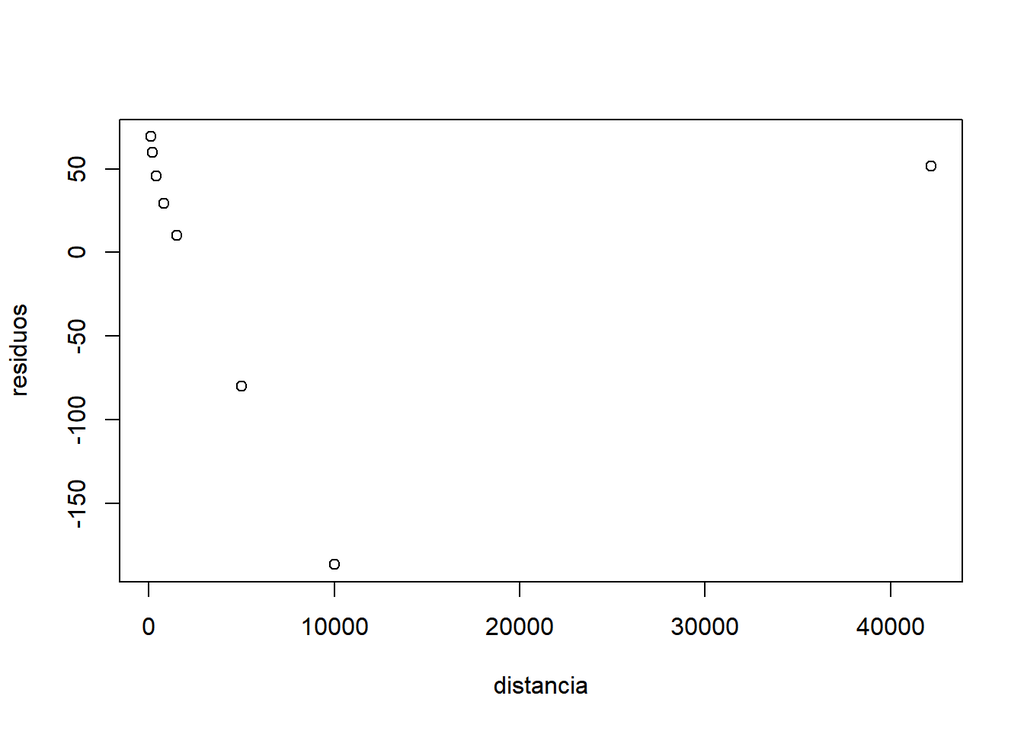

```r
plot(distancia,recta_h$residuals,xlab="distancia",ylab="residuos")
```

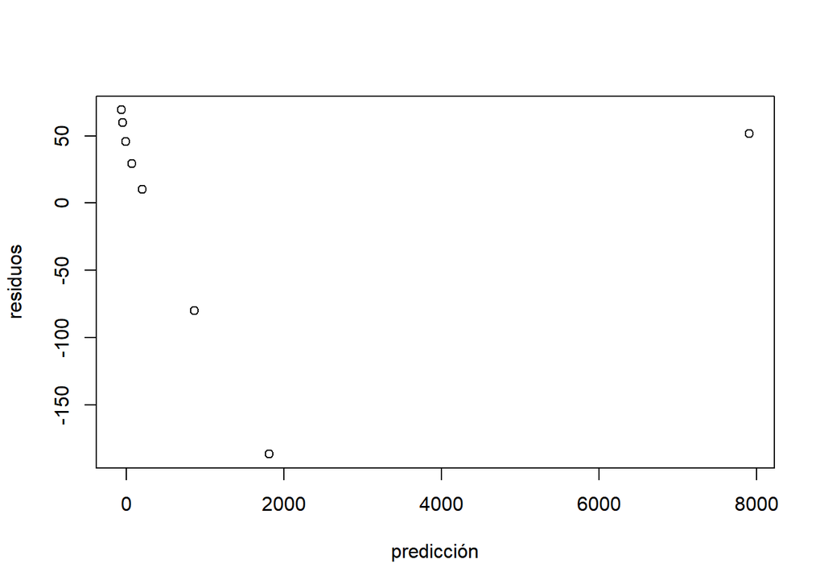

```r
plot(recta_h$fitted.values,recta_h$residuals,xlab="predicción",ylab="residuos")
```

```r
sum(recta_h$residuals^2)
```

```
## [1] 55189
```

```r
summary(recta_h)$r.squared
```

```
## [1] 0.9989417
```

### Apartado B

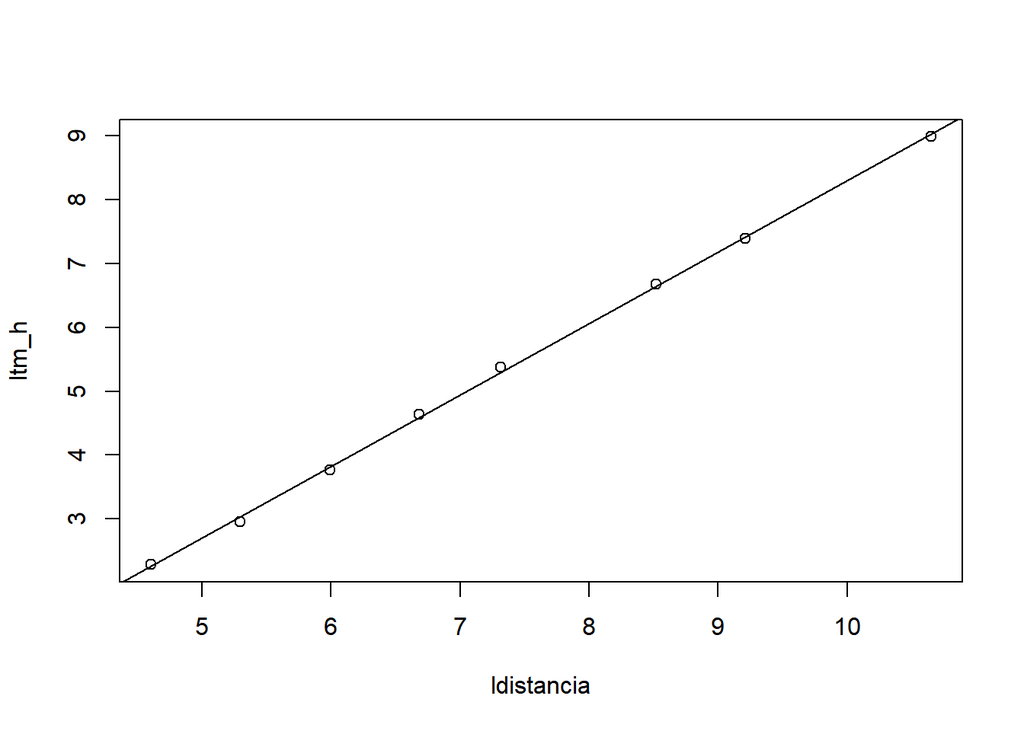

```r
ltm_h <- log(tm_h)
ldistancia <- log(distancia)
recta_lh <- lm(ltm_h~ldistancia)
plot(ldistancia,ltm_h)
abline(recta_lh)
```

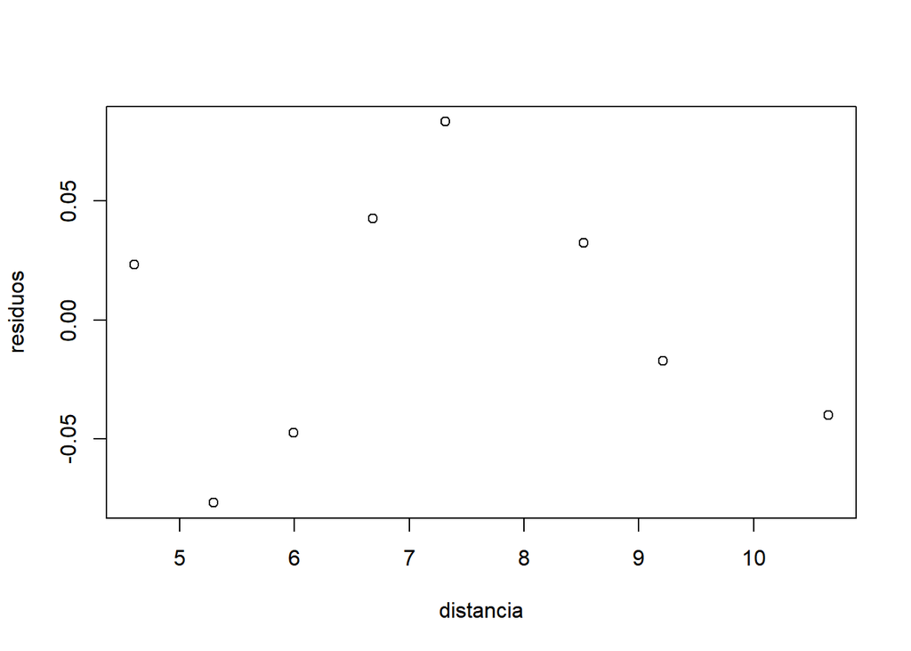

```r
plot(ldistancia,recta_lh$residuals,xlab="distancia",ylab="residuos")
```

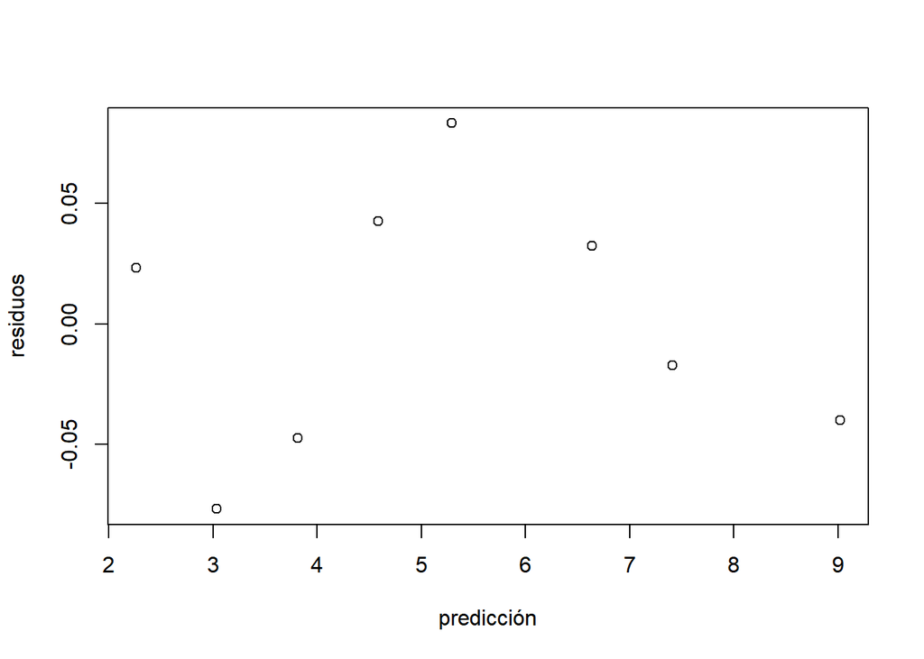

```r
plot(recta_lh$fitted.values,recta_lh$residuals,xlab="predicción",ylab="residuos")
```

```r
sum(recta_lh$residuals^2)
```

```
## [1] 0.02042962
```

```r
summary(recta_lh)$r.squared
```

```
## [1] 0.9994503
```

### Apartado C

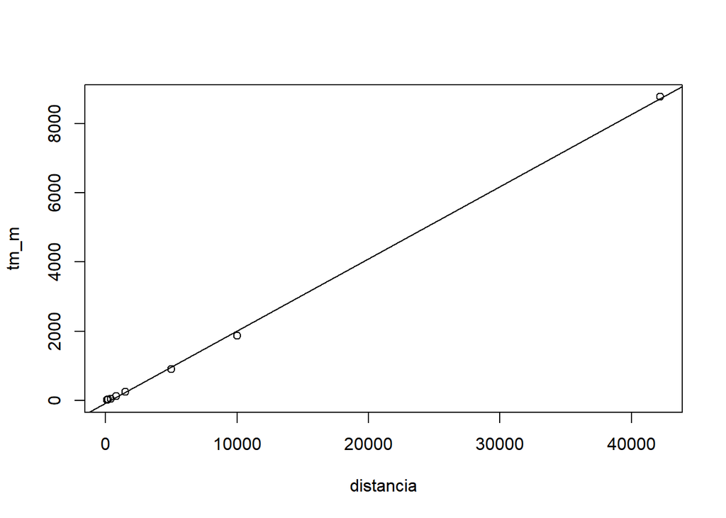

```r
recta_m <- lm(tm_m~distancia)
plot(distancia,tm_m)
abline(recta_m)
```

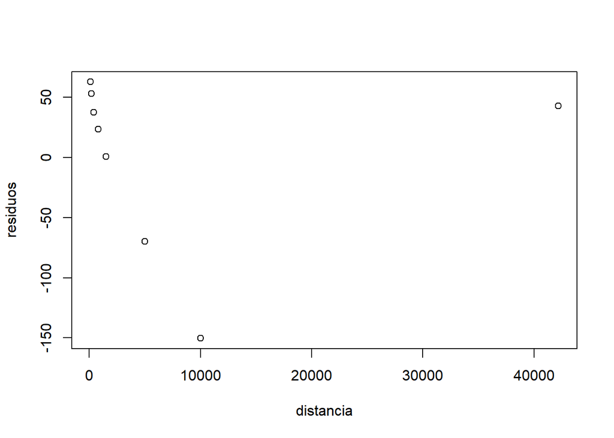

```r
plot(distancia,recta_m$residuals,xlab="distancia",ylab="residuos")
```

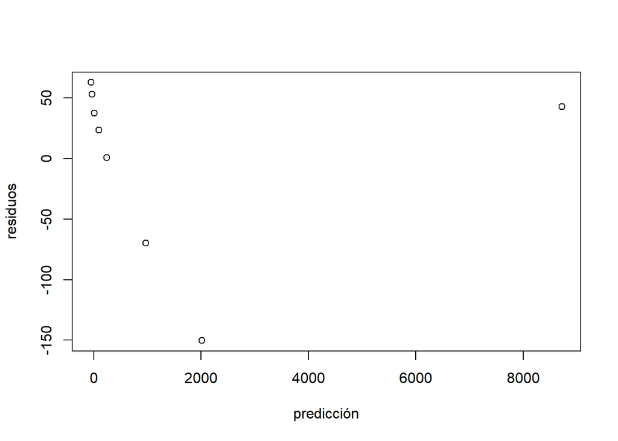

```r
plot(recta_m$fitted.values,recta_m$residuals,xlab="predicción",ylab="residuos")
```

```r
sum(recta_m$residuals^2)
```

```
## [1] 37973.26
```

```r
summary(recta_m)$r.squared
```

```
## [1] 0.9993999
```

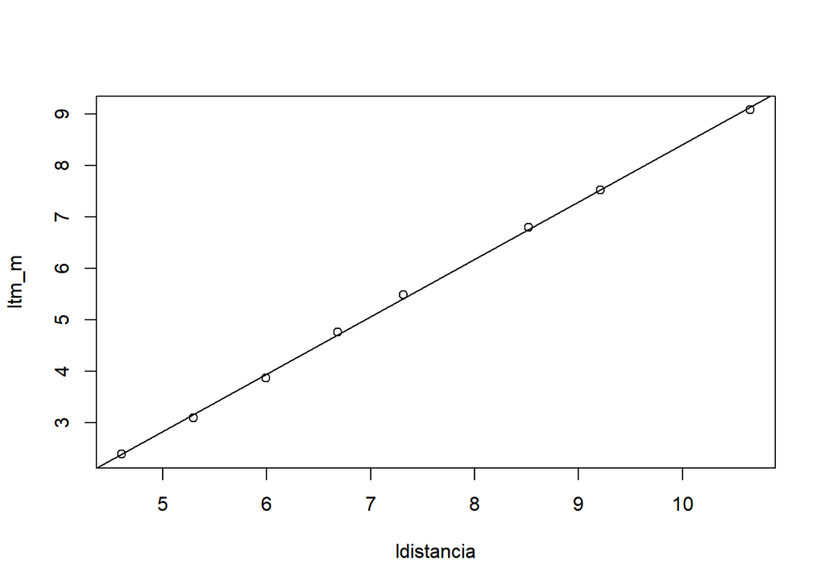

```r
ltm_m <- log(tm_m)
ldistancia <- log(distancia)
recta_lm <- lm(ltm_m~ldistancia)
plot(ldistancia,ltm_m)
abline(recta_lm)
```

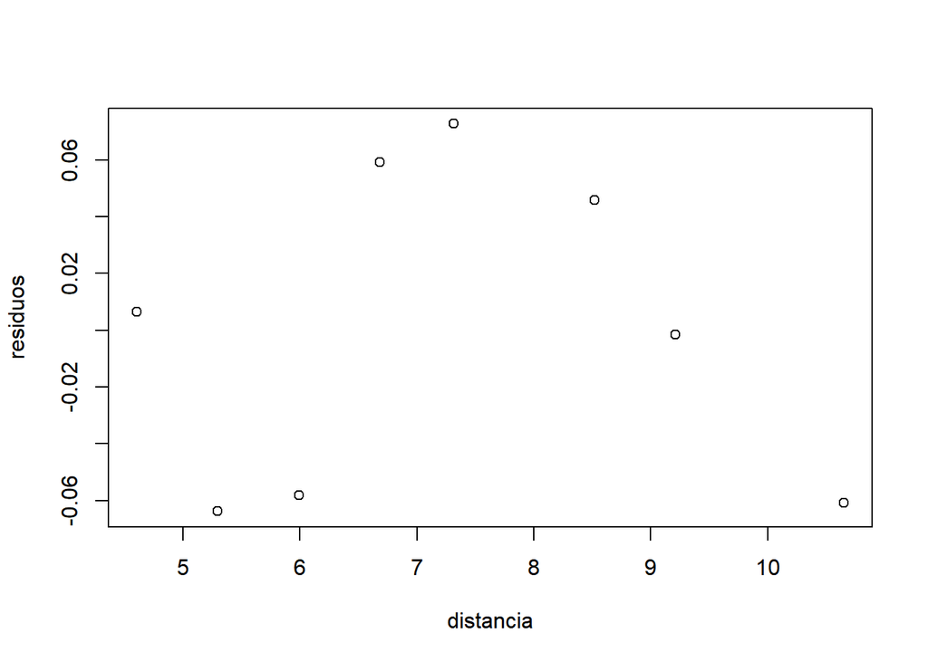

```r
plot(ldistancia,recta_lm$residuals,xlab="distancia",ylab="residuos")
```

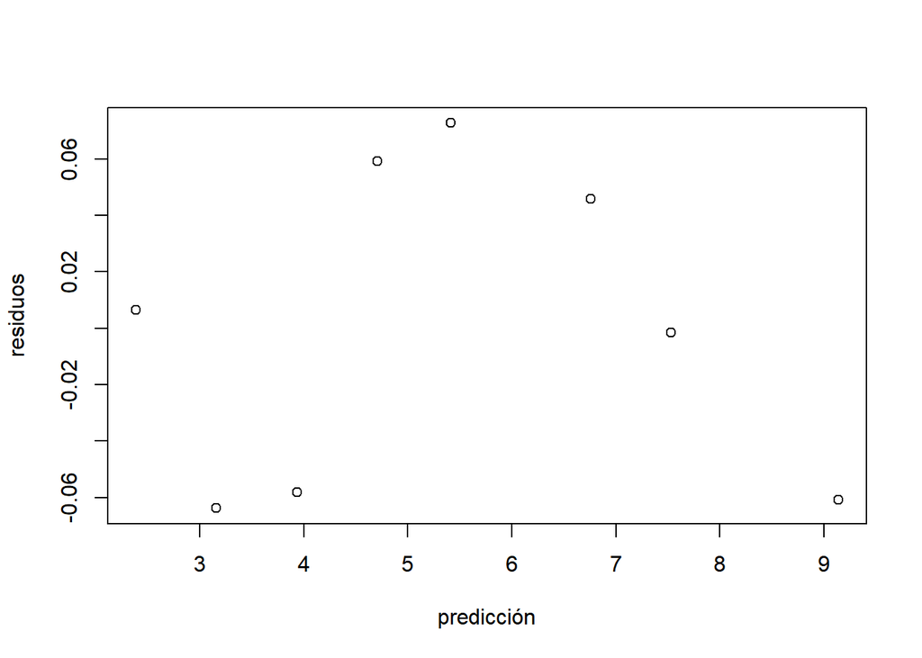

```r
plot(recta_lm$fitted.values,recta_lm$residuals,xlab="predicción",ylab="residuos")
```

```r
sum(recta_lm$residuals^2)
```

```
## [1] 0.02210668
```

```r
summary(recta_lm)$r.squared
```

```
## [1] 0.9994042
```